# Neo Legibility Effort Model

Giseldo da Silva Neo

## Hipótese

A polaridade do sentimento (ou tom) da descrição da User Story, a subjetividade da descrição da User Story e a legibilidade da descrição da da User Story são bons preditores da estimativa de esforço.

Made by Giseldo. [Source Code](https://github.com/giseldo/Neo_Legibility_R_Python)

## Conjunto de dados

#### Conjunto de dados

O [Neo Dataset](https://github.com/giseldo/neodataset) contém as User Story com seus respectivos Story Points de 34 Projetos de desenvolvimento de software.

|  | issuekey | title | description | storypoints |
| --- | --- | --- | --- | --- |
| 0 | 29688087 | Update templates for website merge requests | Relates to &232 and #6109 \r\n\r\nGoals:\r\n\r... | 1 |
| 1 | 29682716 | Make sure that we Capture Advanced Search in o... | This was raised in the PM & Engineering meetin... | 1 |

Made by Giseldo

## Variáveis

As variáveis do conjunto de dados são:

| Variável | Tipo | Preditora ou Rótulo | Descrição |
| --- | --- | --- | --- |
| issuekey | categórica simples | - | Chave |
| created | data e hora | - | Data de criação |
| title | texto | preditora | Título da User Story |
| description | texo | preditora | Descrição da User Story |
| storypoints | numérico discreto | rótulo | Story Point da User Story |

Made by Giseldo

## Transformação

### Projeto 7764

A coluna **title** e **description** foi transformada em uma única coluna chamada **context**. As outras colunas foram removidas pois não trazem dados preditivos.

|  | storypoints | context |
| --- | --- | --- |
| 0 | 1 | Update templates for website merge requestsRel... |
| 1 | 1 | Make sure that we Capture Advanced Search in o... |
| 2 | 1 | Propose new IA for Brand and Digital Handbook#... |
| 3 | 1 | Cache `node_modules` for www-gitlab-com pipeli... |
| 4 | 1 | Disable all remaining unnecessary jobs in pipe... |

Made by Giseldo

## Story Point

### Projeto 7764

Detectado presença de outliers.

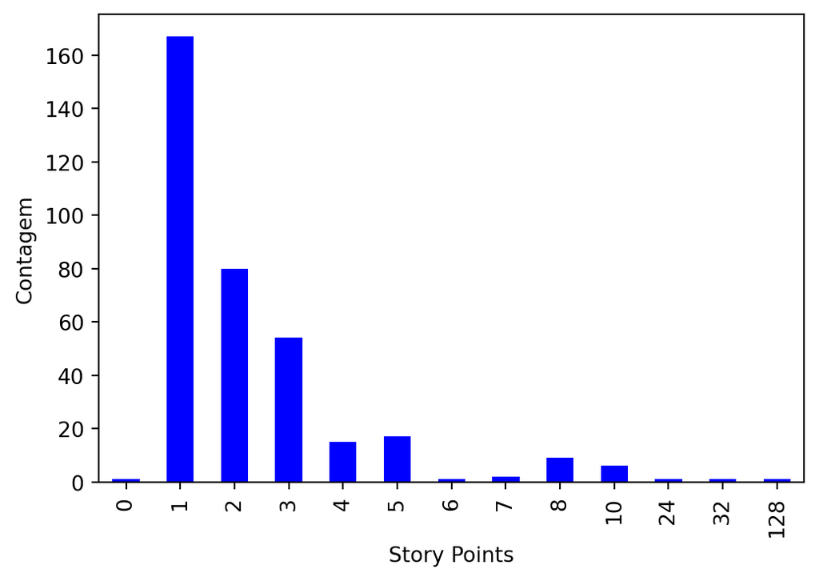

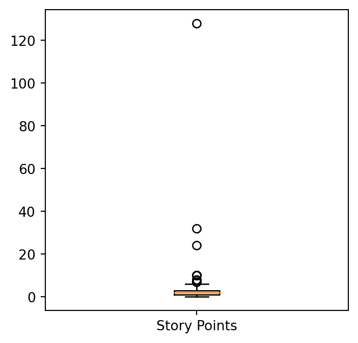

Made by Giseldo

## Outliers

### Projeto 7764

Foram removidos os Story Poits com 2 desvios padrão antes e depois da média.

```r
mean = df['storypoints'].mean()
std_dev = df['storypoints'].std()
outlier_cutoff = 2 * std_dev
df_clean = df[(df['storypoints'] >= mean - outlier_cutoff) & (df['storypoints'] < mean + outlier_cutoff)]
```

Antes da remoção 355 observações. Depois 352 observações.

Made by Giseldo

## Story Point (sem outliers)

### Projeto 7764

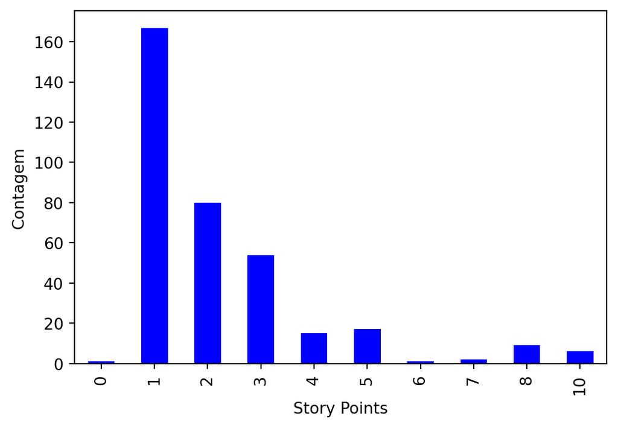

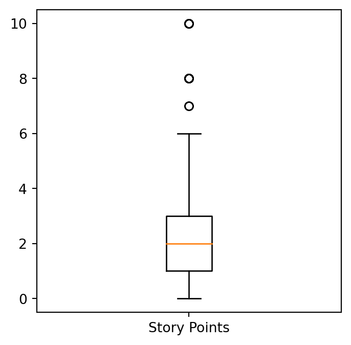

Made by Giseldo

## Data frame

### Projeto 7764

|  | storypoints | context | gunning_fog | polarity | subjectivity |
| --- | --- | --- | --- | --- | --- |
| 249 | 2 | Community contribution pipelines failThere is ... | 7.41 | -0.203409 | 0.276136 |
| 250 | 2 | Reapply redirects in pipeline for testing manu... | 10.11 | 0.159864 | 0.403912 |
| 251 | 1 | Add a visual element on Handbook pages to diff... | 11.00 | 0.143325 | 0.418265 |
| 252 | 1 | Add A beginner's guide to GitOps ebook to topi... | 9.05 | 0.155500 | 0.423587 |
| 253 | 1 | Commit disable scholarship apply buttonAfter t... | 10.64 | 0.000000 | 0.000000 |

Made by Giseldo

## TF-IDF Model

### Projeto 7764

No TF-IDF a coluna context é transformada em uma matriz. Cada palavra é uma coluna dessa matriz. Por isso é interessante o uso de técnicas de pré-processamento de texto (para diminuir o número de palavras que não são relevantes).

| Variável | Tipo | Descrição |
| --- | --- | --- |
| context | texto | título + descrição |
| storypoint | numérico contínuo | Story Point da User Story |

Made by Giseldo

## Neo Legibility

### Projeto 7764

Atributos extraídos da User Story (*)

| Variável | Tipo | Descrição |
| --- | --- | --- |
| *gunning_fog | numérico contínuo | Legibilidade da User Story |
| *polarity | numérico contínuo | Sentimento da User Story |
| *subjectivity | numérico contínuo | Subjetividade da User Story |
| storypoint | numérico contínuo | Story Point da User Story |

Made by Giseldo

## Neo Legibility - Correlação

### Projeto 7764

Existe uma correlação fraca entre gunning_fog e os storypoints.

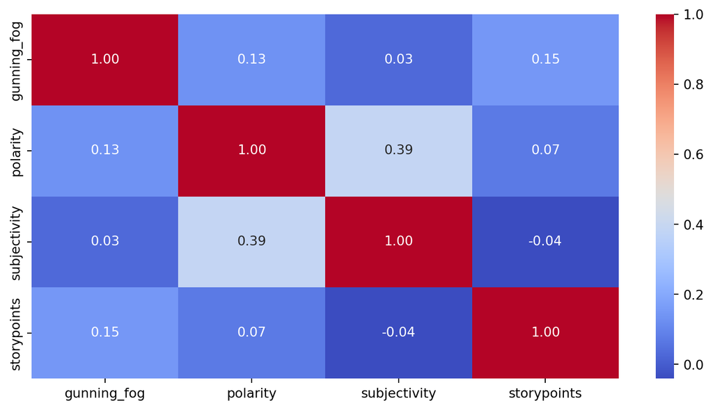

Made by Giseldo

## Resultado comparação entre os MAE dos modelos

### Projeto 7764

O Modelo que tem o menor MAE (erro médio absoluto) é o Neo Legibility.

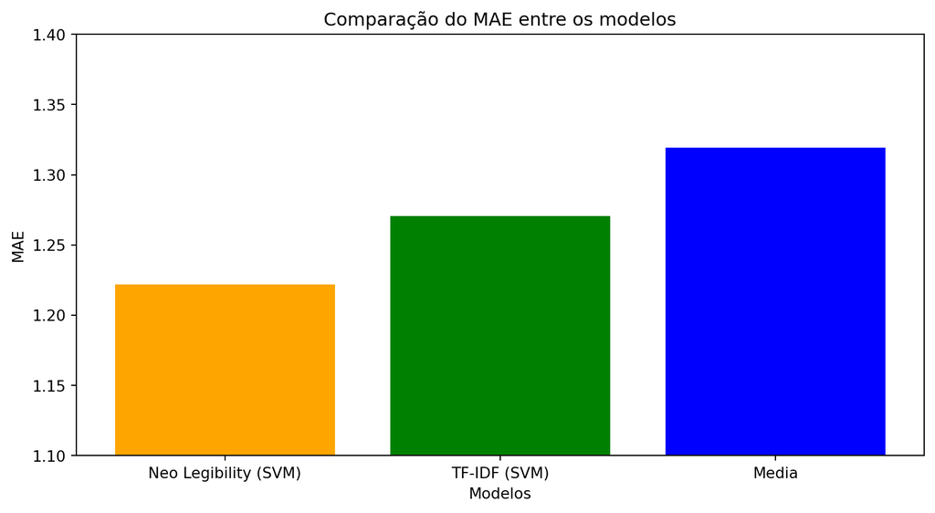

Made by Giseldo

## Resultado Final

Contador de quantas vezes o Neo Legibility teve um MAE menor em cada um dos projetos.

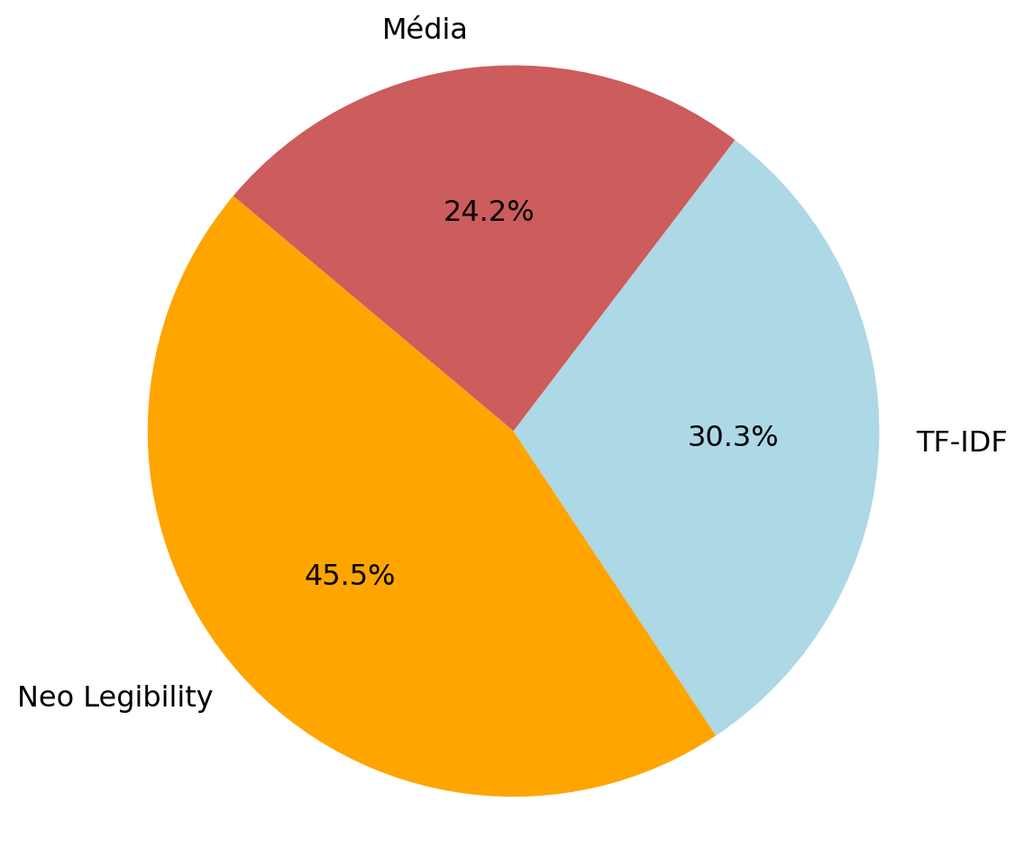